# Lab 1

**Objectives:**

1. Introduce the concept of a data repository,
2. Introduce popular data repositories,
3. Extracting data from databases
4. Exploratory Data Analysis

## Data Repositories

For your final project you need data. You can find good data sources online. The two most popular online sources are:

1. Data repositories: These are websites where people upload datasets for various purposes.
2. Data competition sites: Platforms where you can access datasets for data science competitions.

## Data Source

Here are some websites you can collect your data from:

1. [The UC Irvine Machine Learning Repository](https://archive.ics.uci.edu)
2. [The Harvard Dataverse](https://dataverse.harvard.edu/)
3. [FiveThirtyEight](https://github.com/fivethirtyeight/)
4. [NYtimes](https://github.com/nytimes)
5. [Kaggle](https://www.kaggle.com)
6. [The International Data Analysis Olympiad](https://idao.world/)

Check out these links for a few minutes!

## Data Extraction

Let's see how you can use a repository to access data. Note that I'm not assuming you know any of these! So let me know if you have any questions.

### Example 1

Check this out:

[How Baby Boomers Get High](https://fivethirtyeight.com/features/how-baby-boomers-get-high/)

1. Go to the link associated with the data file https://github.com/fivethirtyeight/data/blob/master/drug-use-by-age/drug-use-by-age.csv
2. Click on the `Raw` button above the data table on the page.
3. Save the file as `drug-use-by-age.csv`, and upload it to Google Colab
4. Run the code chunks below.

```python
import pandas as pd
```

```python
data = pd.read_csv("drug-use-by-age.csv")
```

Let's look at the first 5 rows of our data

```python
data.head()
```

|  | age | n | alcohol_use | alcohol_frequency | marijuana_use | marijuana_frequency | cocaine_use | cocaine_frequency | crack_use | crack_frequency | ... | oxycontin_use | oxycontin_frequency | tranquilizer_use | tranquilizer_frequency | stimulant_use | stimulant_frequency | meth_use | meth_frequency | sedative_use | sedative_frequency |
| --- | --- | --- | --- | --- | --- | --- | --- | --- | --- | --- | --- | --- | --- | --- | --- | --- | --- | --- | --- | --- | --- |
| 0 | 12 | 2798 | 3.9 | 3.0 | 1.1 | 4.0 | 0.1 | 5.0 | 0.0 | - | ... | 0.1 | 24.5 | 0.2 | 52.0 | 0.2 | 2.0 | 0.0 | - | 0.2 | 13.0 |
| 1 | 13 | 2757 | 8.5 | 6.0 | 3.4 | 15.0 | 0.1 | 1.0 | 0.0 | 3.0 | ... | 0.1 | 41.0 | 0.3 | 25.5 | 0.3 | 4.0 | 0.1 | 5.0 | 0.1 | 19.0 |
| 2 | 14 | 2792 | 18.1 | 5.0 | 8.7 | 24.0 | 0.1 | 5.5 | 0.0 | - | ... | 0.4 | 4.5 | 0.9 | 5.0 | 0.8 | 12.0 | 0.1 | 24.0 | 0.2 | 16.5 |
| 3 | 15 | 2956 | 29.2 | 6.0 | 14.5 | 25.0 | 0.5 | 4.0 | 0.1 | 9.5 | ... | 0.8 | 3.0 | 2.0 | 4.5 | 1.5 | 6.0 | 0.3 | 10.5 | 0.4 | 30.0 |
| 4 | 16 | 3058 | 40.1 | 10.0 | 22.5 | 30.0 | 1.0 | 7.0 | 0.0 | 1.0 | ... | 1.1 | 4.0 | 2.4 | 11.0 | 1.8 | 9.5 | 0.3 | 36.0 | 0.2 | 3.0 |

5 rows × 28 columns

```python
# Find the first 10 rows
# code here
print(data.head(10))
```

```
  age     n  alcohol_use  alcohol_frequency  marijuana_use  \
0  12  2798          3.9                3.0            1.1
1  13  2757          8.5                6.0            3.4
2  14  2792         18.1                5.0            8.7
3  15  2956         29.2                6.0           14.5
4  16  3058         40.1               10.0           22.5
5  17  3038         49.3               13.0           28.0
6  18  2469         58.7               24.0           33.7
7  19  2223         64.6               36.0           33.4
8  20  2271         69.7               48.0           34.0
9  21  2354         83.2               52.0           33.0

   marijuana_frequency  cocaine_use cocaine_frequency  crack_use  \
0                  4.0          0.1               5.0        0.0
1                 15.0          0.1               1.0        0.0
```

[output cut: 46 more lines]

```python
# Print the last 5 row?
# code here
print(data.tail(5))
```

```
      age     n  alcohol_use  alcohol_frequency  marijuana_use  \
12  26-29  2628         80.7               52.0           20.8
13  30-34  2864         77.5               52.0           16.4
14  35-49  7391         75.0               52.0           10.4
15  50-64  3923         67.2               52.0            7.3
16    65+  2448         49.3               52.0            1.2

    marijuana_frequency  cocaine_use cocaine_frequency  crack_use  \
12                 52.0          3.2               5.0        0.4
13                 72.0          2.1               8.0        0.5
14                 48.0          1.5              15.0        0.5
15                 52.0          0.9              36.0        0.4
16                 36.0          0.0                 -        0.0

   crack_frequency  ...  oxycontin_use oxycontin_frequency  tranquilizer_use  \
```

[output cut: 21 more lines]

```python
#check what the function data.sample()does. What happens if you toss a number inside those parentheses (as an argument)?
print(data.sample())

"""
If you toss a number inside the parentheses, you will get a number of random entries equal to the parameter you put inside the parenteses.
"""
```

```
      age     n  alcohol_use  alcohol_frequency  marijuana_use  \
11  24-25  4591         83.1               52.0           24.9

    marijuana_frequency  cocaine_use cocaine_frequency  crack_use  \
11                 60.0          4.0               6.0        0.5

   crack_frequency  ...  oxycontin_use oxycontin_frequency  tranquilizer_use  \
11             6.0  ...            1.3                20.0               4.3

    tranquilizer_frequency  stimulant_use stimulant_frequency  meth_use  \
11                    10.0            2.6                10.0       0.7

    meth_frequency  sedative_use sedative_frequency
11            21.0           0.2               17.5

[1 rows x 28 columns]
```

Lets have a overall look of the dataset, checking if there is any inconsistency in the Dataset.

```python
print('Rows:',data.shape[0])
print('Columns:',data.shape[1])
```

```
Rows: 17
Columns: 28
```

```python
print('Columns (features)')
print()
print( data.columns.tolist())
```

```
Columns (features)

['age', 'n', 'alcohol_use', 'alcohol_frequency', 'marijuana_use', 'marijuana_frequency', 'cocaine_use', 'cocaine_frequency', 'crack_use', 'crack_frequency', 'heroin_use', 'heroin_frequency', 'hallucinogen_use', 'hallucinogen_frequency', 'inhalant_use', 'inhalant_frequency', 'pain_releiver_use', 'pai…
```

```python
print(' Unique Values')
print()
print( data.nunique())
```

```
 Unique Values

age                        17
n                          17
alcohol_use                16
alcohol_frequency           9
marijuana_use              17
marijuana_frequency        10
cocaine_use                14
cocaine_frequency          10
crack_use                   5
crack_frequency            13
heroin_use                  9
heroin_frequency           17
hallucinogen_use           16
hallucinogen_frequency      6
inhalant_use               15
inhalant_frequency         11
pain_releiver_use          15
pain_releiver_frequency    10
oxycontin_use              12
oxycontin_frequency        15
tranquilizer_use           15
tranquilizer_frequency     10
stimulant_use              16
stimulant_frequency        11
meth_use                    9
meth_frequency             14
sedative_use                6
sedative_frequency         14
dtype: int64
```

Here is another useful function:

```python
data.info()
```

```
<class 'pandas.core.frame.DataFrame'>
RangeIndex: 17 entries, 0 to 16
Data columns (total 28 columns):
 #   Column                   Non-Null Count  Dtype
---  ------                   --------------  -----
 0   age                      17 non-null     object
 1   n                        17 non-null     int64
 2   alcohol_use              17 non-null     float64
 3   alcohol_frequency        17 non-null     float64
 4   marijuana_use            17 non-null     float64
 5   marijuana_frequency      17 non-null     float64
 6   cocaine_use              17 non-null     float64
 7   cocaine_frequency        17 non-null     object
 8   crack_use                17 non-null     float64
 9   crack_frequency          17 non-null     object
```

[output cut: 20 more lines]

We can also load the directly from the website by placing the raw csv file directly into `.read_csv`.

```python
#Code here
data = pd.read_csv("https://raw.githubusercontent.com/fivethirtyeight/data/master/drug-use-by-age/drug-use-by-age.csv")
```

Can you filter your table to have information only among people in the age range 20-50

```python
#Code here
import numpy as np
# print(data.loc['age'])
index_list = np.array([9,15])
print(data.iloc[9:15])
```

```
      age     n  alcohol_use  alcohol_frequency  marijuana_use  \
9      21  2354         83.2               52.0           33.0
10  22-23  4707         84.2               52.0           28.4
11  24-25  4591         83.1               52.0           24.9
12  26-29  2628         80.7               52.0           20.8
13  30-34  2864         77.5               52.0           16.4
14  35-49  7391         75.0               52.0           10.4

    marijuana_frequency  cocaine_use cocaine_frequency  crack_use  \
9                  52.0          4.8               5.0        0.5
10                 52.0          4.5               5.0        0.5
11                 60.0          4.0               6.0        0.5
12                 52.0          3.2               5.0        0.4
13                 72.0          2.1               8.0        0.5
14                 48.0          1.5              15.0        0.5
```

[output cut: 26 more lines]

Let's plot this new table using scatter matrix.

[output not shown]

[output cut: 387 more lines]

[output not shown]

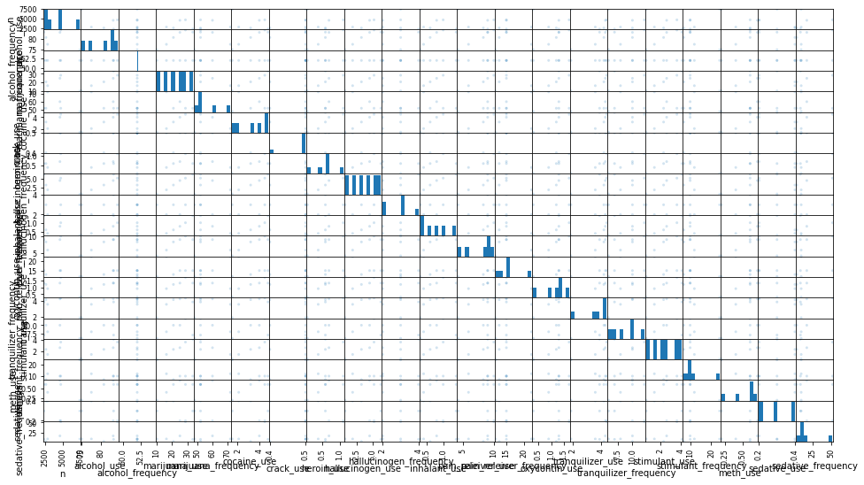

```python
#Code here
pd.plotting.scatter_matrix(data.iloc[9:15], figsize=(16,9), alpha=0.2)
```

### Example: Extracting Data from Kaggle.com

Let's now show you how to grab some data from Kaggle.com. Heads up, **you'll need a Kaggle profile for this**.

Kaggle has a whole section dedicated to public datasets, [here](https://www.kaggle.com/datasets). Today, we're downloading the famous iris dataset from [this link](https://www.kaggle.com/uciml/iris).

#### Instructions

1. Go to this [link](https://www.kaggle.com/uciml/iris).
2. Download and unzip the zip file. Then upload the `Iris.csv` to Google Colab page.

```python
#Read the Iris.csv file using pandas
iris_data = pd.read_csv("Iris.csv")
```

```python
#Examine the first five and the last five rows.
print(iris_data.head(5))
print(iris_data.tail(5))
```

```
   Id  SepalLengthCm  SepalWidthCm  PetalLengthCm  PetalWidthCm      Species
0   1            5.1           3.5            1.4           0.2  Iris-setosa
1   2            4.9           3.0            1.4           0.2  Iris-setosa
2   3            4.7           3.2            1.3           0.2  Iris-setosa
3   4            4.6           3.1            1.5           0.2  Iris-setosa
4   5            5.0           3.6            1.4           0.2  Iris-setosa
      Id  SepalLengthCm  SepalWidthCm  PetalLengthCm  PetalWidthCm  \
145  146            6.7           3.0            5.2           2.3
146  147            6.3           2.5            5.0           1.9
147  148            6.5           3.0            5.2           2.0
148  149            6.2           3.4            5.4           2.3
149  150            5.9           3.0            5.1           1.8

            Species
145  Iris-virginica
146  Iris-virginica
147  Iris-virginica
148  Iris-virginica
149  Iris-virginica
```

```python
#Examine a random sample
print(iris_data.sample())
```

```
      Id  SepalLengthCm  SepalWidthCm  PetalLengthCm  PetalWidthCm  \
139  140            6.9           3.1            5.4           2.1

            Species
139  Iris-virginica
```

There is no inconsistency because there are no null values!

```python
#Explor the data and check if there is any inconsistency in the Dataset.
print(iris_data.info())
```

```
<class 'pandas.core.frame.DataFrame'>
RangeIndex: 150 entries, 0 to 149
Data columns (total 6 columns):
 #   Column         Non-Null Count  Dtype
---  ------         --------------  -----
 0   Id             150 non-null    int64
 1   SepalLengthCm  150 non-null    float64
 2   SepalWidthCm   150 non-null    float64
 3   PetalLengthCm  150 non-null    float64
 4   PetalWidthCm   150 non-null    float64
 5   Species        150 non-null    object
dtypes: float64(4), int64(1), object(1)
memory usage: 7.2+ KB
None
```

## Exploratory Data Analysis

Exploratory Data Analysis (EDA) is a critical step in data analysis that identifies general patterns and relations in the data.

Now lets try to plot the data and have some ideas about the relation between different columns.

[output not shown]

[output cut: 387 more lines]

[output not shown]

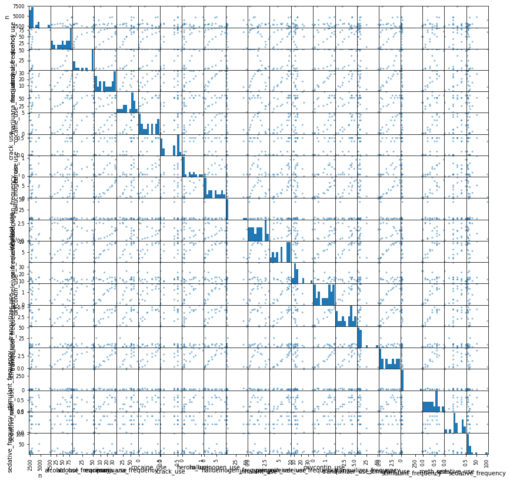

```python
from pandas.plotting import scatter_matrix
import matplotlib.pyplot as plt


scatter_matrix(data, figsize=(14,14))

#plt.show()
```

When we're training algorithms, we need to pay attention to how many features we've got and how they relate to each other. If we've got a bunch of features that are all tangled up (correlated), using them all can mess with our accuracy. So, we've got to be smart about picking the right ones. But how?

In machine learning and data analysis, understanding feature correlations is important because highly correlated features can sometimes provide redundant or overlapping information to algorithms, which can lead to suboptimal model performance. Therefore, feature selection or feature engineering techniques are used to choose the most relevant and uncorrelated features for modeling.

**Correlation** We say two or more features (variables) in a dataset are correlated if there is a statistical relationship or association between them. When features are correlated, changes in one feature may be related to changes in another.

For example, if you have two features in a dataset, such as "temperature" and "ice cream sales," and you notice that as the temperature increases, ice cream sales also tend to increase, these two features can be considered correlated. In simpler terms, when one goes up, the other often goes up as well, or vice versa. In most data, pairwise correlations may not provide enough insights, and multivariate appraoches to exploratory data analyses are recommended.

```python
# use .corr() to find pairwise correlation in CSV file of example 1
print(data.corr())
```

```
                                n  alcohol_use  alcohol_frequency  \
n                        1.000000     0.310512           0.313431
alcohol_use              0.310512     1.000000           0.897889
alcohol_frequency        0.313431     0.897889           1.000000
marijuana_use           -0.169007     0.594165           0.260219
marijuana_frequency      0.135597     0.920425           0.818769
cocaine_use             -0.021565     0.773458           0.577601
crack_use                0.281797     0.877378           0.785050
heroin_use               0.007798     0.677614           0.546194
hallucinogen_use        -0.295302     0.463702           0.182184
hallucinogen_frequency   0.008743    -0.346643          -0.174622
inhalant_use            -0.368395    -0.648248          -0.864153
pain_releiver_use       -0.083587     0.617523           0.280704
pain_releiver_frequency -0.112076    -0.263721           0.007087
oxycontin_use           -0.166039     0.589219           0.251554
tranquilizer_use        -0.071086     0.735785           0.448543
tranquilizer_frequency  -0.102301    -0.550501          -0.415026
stimulant_use           -0.201621     0.582241           0.291766
stimulant_frequency     -0.114792    -0.028115           0.260304
meth_use                -0.063571     0.682531           0.425153
sedative_use            -0.119997     0.318268           0.029867
sedative_frequency       0.256701     0.091251           0.201423

                         marijuana_use  marijuana_frequency  cocaine_use  \
n                            -0.169007             0.135597    -0.021565
alcohol_use                   0.594165             0.920425     0.773458
alcohol_frequency             0.260219             0.818769     0.577601
marijuana_use                 1.000000             0.615610     0.883789
marijuana_frequency           0.615610             1.000000     0.742598
cocaine_use                   0.883789             0.742598     1.000000
crack_use                     0.620670             0.892077     0.835727
heroin_use                    0.711613             0.631789     0.899944
hallucinogen_use              0.959353             0.528733     0.855668
hallucinogen_frequency       -0.478286            -0.380430    -0.368402
inhalant_use                  0.127336            -0.577792    -0.214609
pain_releiver_use             0.966226             0.612254     0.906638
pain_releiver_frequency      -0.506892            -0.285292    -0.273908
oxycontin_use                 0.971733             0.609618     0.865626
tranquilizer_use              0.935199             0.768339     0.920430
tranquilizer_frequency       -0.401769            -0.591449    -0.294905
```

[output cut: 130 more lines]

```
hallucinogen_use             0.518700           -0.312746
hallucinogen_frequency      -0.231773            0.533095
inhalant_use                 0.110611           -0.293189
pain_releiver_use            0.636666           -0.271246
pain_releiver_frequency     -0.378001           -0.045213
oxycontin_use                0.625929           -0.198329
tranquilizer_use             0.674618           -0.224045
tranquilizer_frequency      -0.245645           -0.014524
stimulant_use                0.567956           -0.260968
stimulant_frequency         -0.526289           -0.011796
meth_use                     0.663079           -0.187589
sedative_use                 1.000000           -0.284234
sedative_frequency          -0.284234            1.000000

[21 rows x 21 columns]
```

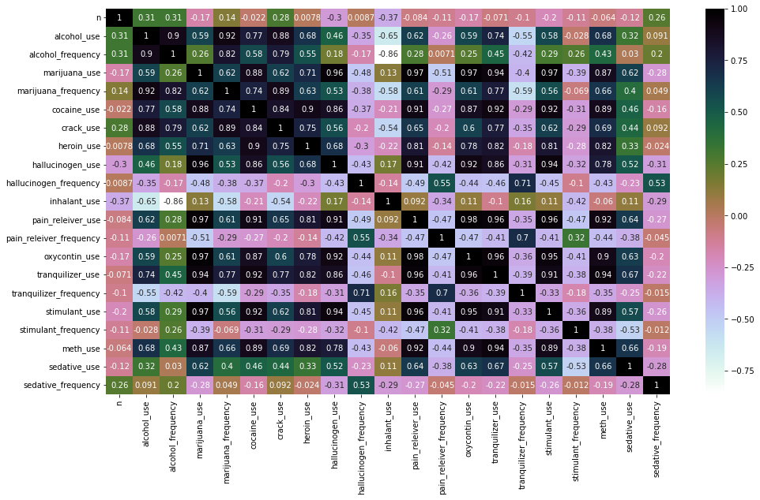

```python
# run this code for a better view
plt.figure(figsize=(16,9))
import seaborn as sns

sns.heatmap(data.corr(), annot=True, cmap='cubehelix_r')
plt.show()
```

Let's say your project focuses on only alcohol, marijuana and cocain. Create a table that specifically captures data on alcohol, marijuana, and cocaine.

```python
# code here
data1 = data.iloc[0:15]
data1 = data1[['alcohol_use','alcohol_frequency','marijuana_use','marijuana_frequency','cocaine_frequency']]

data1['cocaine_frequency'] = pd.to_numeric(data1['cocaine_frequency'])
print(data1)
```

```
    alcohol_use  alcohol_frequency  marijuana_use  marijuana_frequency  \
0           3.9                3.0            1.1                  4.0
1           8.5                6.0            3.4                 15.0
2          18.1                5.0            8.7                 24.0
3          29.2                6.0           14.5                 25.0
4          40.1               10.0           22.5                 30.0
5          49.3               13.0           28.0                 36.0
6          58.7               24.0           33.7                 52.0
7          64.6               36.0           33.4                 60.0
8          69.7               48.0           34.0                 60.0
9          83.2               52.0           33.0                 52.0
10         84.2               52.0           28.4                 52.0
11         83.1               52.0           24.9                 60.0
12         80.7               52.0           20.8                 52.0
13         77.5               52.0           16.4                 72.0
```

[output cut: 18 more lines]